# JHU and SwiftKey Data Science Capstone Project: Natural Language Proecssing

### Corpus Buidling and Preparation

Build corpus from the merge text file above:

```r
corpus <- VCorpus(VectorSource(txt))
```

A list of profanity words were obtained from this [soruce](http://www.freewebheaders.com/full-list-of-bad-words-banned-by-google/)

```r
# read list of bad words
badwords    <- VectorSource(readLines("badwords.txt"))
# remove profanity words
corpus.tmp <- tm_map(corpus, removeWords, badwords)
# convert letters to lower case
corpous.tmp <- tm_map(corpus.tmp, content_transformer(tolower))
# remove white spaces
corpus.tmp <- tm_map(corpus.tmp, stripWhitespace)
# remove numbers
corpus.tmp <- tm_map(corpus.tmp, removeNumbers)
# remove puncuations
corpus.tmp <- tm_map(corpus.tmp, removePunctuation)
```

```
## Please make sure you clean the corpus first with the doClean argument equal to TRUE.
## Ignore this message if corpus has already been cleaned.
```

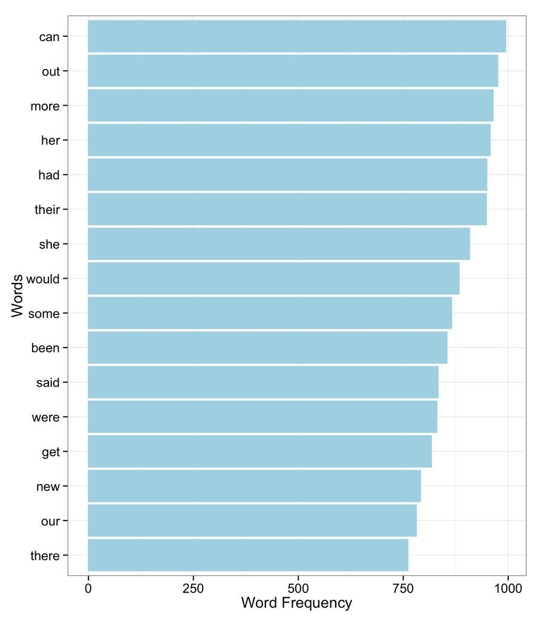

```r
ITSA::generateFreqPlot(corpus, doClean = FALSE, minfreq = 750, horizontal = TRUE)
```

We can also visualize the most frequent terms in the corpus by making a wordcloud. This is shown below:

```
## Please make sure you clean the corpus first with the doClean argument equal to TRUE.
## Ignore this message if corpus has already been cleaned.
```

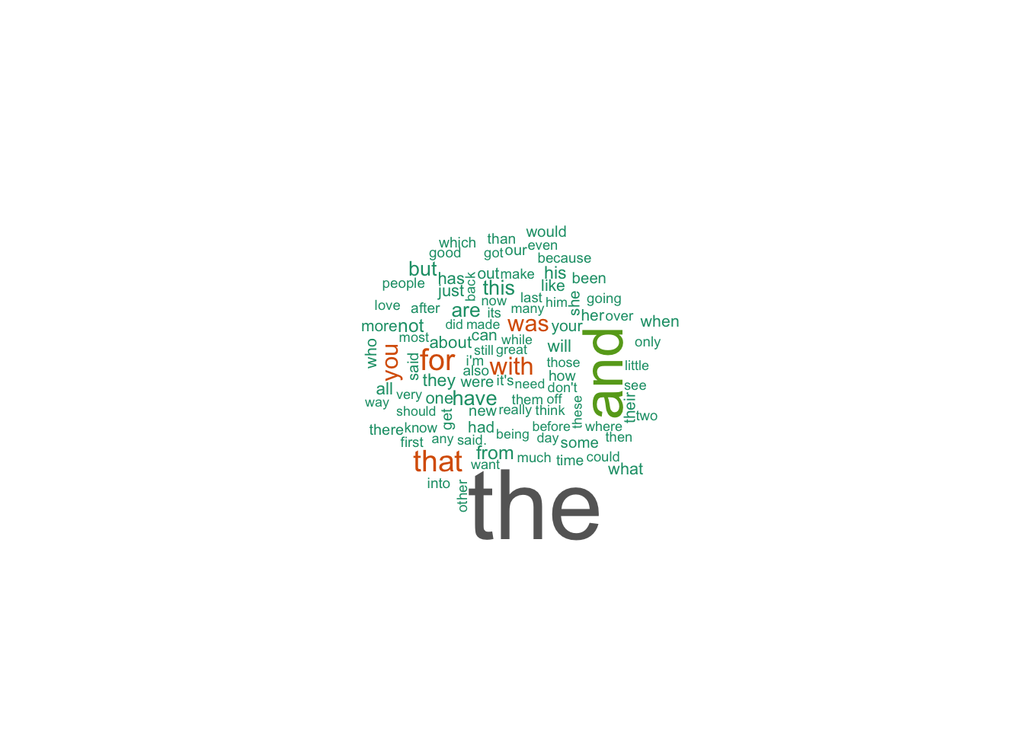

```r
ITSA::generateWordcloud(corpus, freq = 10)
```

### N-gram Words

To make our probabilistic model we need to find out which words are most likely to follow a given word. We will thus be making bi-, tri-, and quad-grams

```r
# Specify the number of threads that the parallel library uses by default to be equal to 1
options(mc.cores=1)
# obtain bi-grams
bigramTokenizer <- function(x) NGramTokenizer(x, Weka_control(min=2, max=2))
# bi-gram DTM
bigramTDM <- TermDocumentMatrix(corpus.tmp, control=list(tokenize=bigramTokenizer))
# do the same for tri- and quad-grams
trigramTokenizer <- function(x) NGramTokenizer(x, Weka_control(min=3, max=3))
trigramTDM       <- TermDocumentMatrix(corpus.tmp, control=list(tokenize=trigramTokenizer))
quadgramTokenizer <- function(x) NGramTokenizer(x, Weka_control(min=4, max=4))
quadgramTDM       <- TermDocumentMatrix(corpus.tmp, control=list(tokenize=quadgramTokenizer))
```

[figure not shown]

```r
frequencies <- sort(rowSums(as.matrix(bigramTDM)), decreasing=TRUE)
wf <- data.frame(words = names(frequencies), freq = frequencies)
wf <- wf[wf$freq >= 10, ]
ggplot(wf, aes(x=reorder(words, freq), y=freq)) + geom_bar(stat="identity", fill="blue") + theme_bw() +
        ylab("Frequency") + xlab("bi-grams") + coord_flip()
```

## Next Steps

After we have done some exploratory data analysis we would like to do the following:

1. Sample the full data sets and try maybe even get more data. In this EDA we only sampled a fraction of the data sets we have. To have more acureate probabilistic model we need larger corpora and more sources.
2. Build a tri-gram, bi-gram, and uni-gram models using the larger data sets.
3. A Shiny application that utilizes the probabilistic model created. This Shiny app will take text as an input and predicts the next word. The app would give the three highest likely words for each word entered.